```python
import numpy as np
import pandas as pd
import matplotlib.pyplot as plt
import seaborn as sns
import warnings
%matplotlib inline
warnings.filterwarnings("ignore")
```

# Export Data

```python
exp=pd.read_csv('/kaggle/input/india-trade-data/2018-2010_export.csv')
exp.head()
```

|  | HSCode | Commodity | value | country | year |
| --- | --- | --- | --- | --- | --- |
| 0 | 2 | MEAT AND EDIBLE MEAT OFFAL. | 0.18 | AFGHANISTAN TIS | 2018 |
| 1 | 3 | FISH AND CRUSTACEANS, MOLLUSCS AND OTHER AQUAT... | 0.00 | AFGHANISTAN TIS | 2018 |
| 2 | 4 | DAIRY PRODUCE; BIRDS' EGGS; NATURAL HONEY; EDI... | 12.48 | AFGHANISTAN TIS | 2018 |
| 3 | 6 | LIVE TREES AND OTHER PLANTS; BULBS; ROOTS AND ... | 0.00 | AFGHANISTAN TIS | 2018 |
| 4 | 7 | EDIBLE VEGETABLES AND CERTAIN ROOTS AND TUBERS. | 1.89 | AFGHANISTAN TIS | 2018 |

```python
### checking Data types

exp.dtypes
```

```
HSCode         int64
Commodity     object
value        float64
country       object
year           int64
dtype: object
```

-------------------------------------------------------> Datatypes are good

```python
### Checking for null values

exp.isnull().sum()
```

```
HSCode           0
Commodity        0
value        14038
country          0
year             0
dtype: int64
```

# Sanity Check for export data

```python
### Value must be >=0

exp[exp['value']<0.0].shape[0]
```

```
0
```

# Visualization for export data

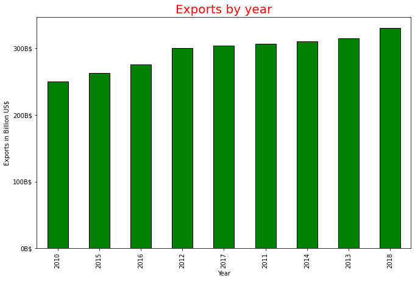

```python
### In Which year India exported highest in value
plt.figure(figsize=[11,7])
exp.groupby(by='year')['value'].sum().sort_values(ascending=True).plot.bar(color='green',edgecolor='Black')
plt.xlabel('Year')
plt.ylabel('Exports in Billion US$')
ticks = np.arange(0, 400000, 100000)
labels = ["{}B$".format(i//1000) for i in ticks]
plt.yticks(ticks, labels)
plt.title('Exports by year',fontdict={'fontsize': 20,'color':'Red'})
plt.show()
```

*Inference: In 2018,India exported highest in value while in 2010 it was lowest*

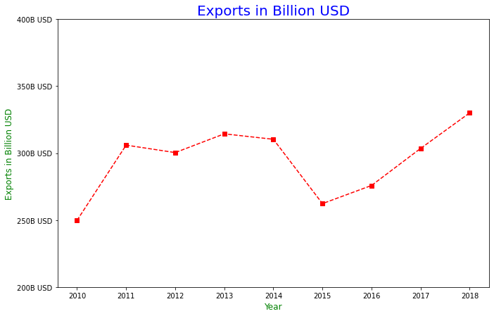

```python
### Exports trend during 2010-2018 using line plot

plt.figure(figsize=[11,7])
exp.groupby(by='year')['value'].sum().plot.line(color='red',marker='s',linestyle='--')
ticks = np.arange(200000, 450000, 50000)
labels = ["{}B USD".format(i//1000) for i in ticks]
plt.yticks(ticks, labels)
plt.xlabel('Year',fontdict={'fontsize': 12,'color':'green'})
plt.ylabel('Exports in Billion USD',fontdict={'fontsize': 12,'color':'green'})
plt.title('Exports in Billion USD',fontdict={'fontsize': 20,'color':'Blue'})
plt.show()
```

*Inference 2:India's export is continously increasing after 2015*

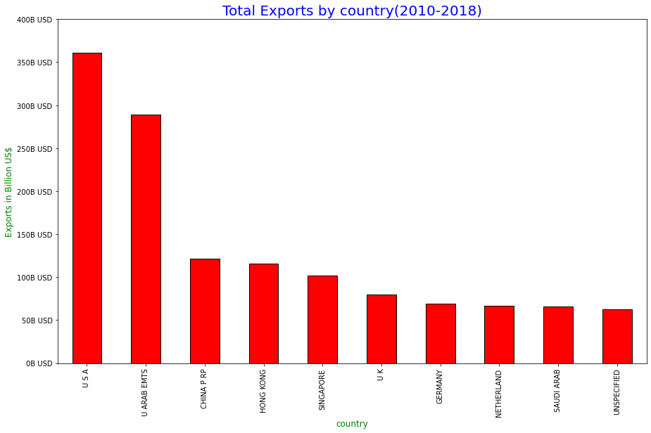

```python
### To which country India exported highest?

plt.figure(figsize=[15,9])
a=exp.groupby(by=['country'])['value'].sum().sort_values(ascending=False).head(10)
a.plot(kind='bar',color='red',edgecolor='black')
plt.xlabel('country',fontdict={'fontsize': 12,'color':'green'})
plt.ylabel('Exports in Billion US$',fontdict={'fontsize': 12,'color':'green'})
plt.title('Total Exports by country(2010-2018)',fontdict={'fontsize': 20,'color':'Blue'})
ticks = np.arange(0, 450000, 50000)
labels = ["{}B USD".format(i//1000) for i in ticks]
plt.yticks(ticks, labels)
plt.show()
```

*India exported highest(by value) to USA(2010-2018)*

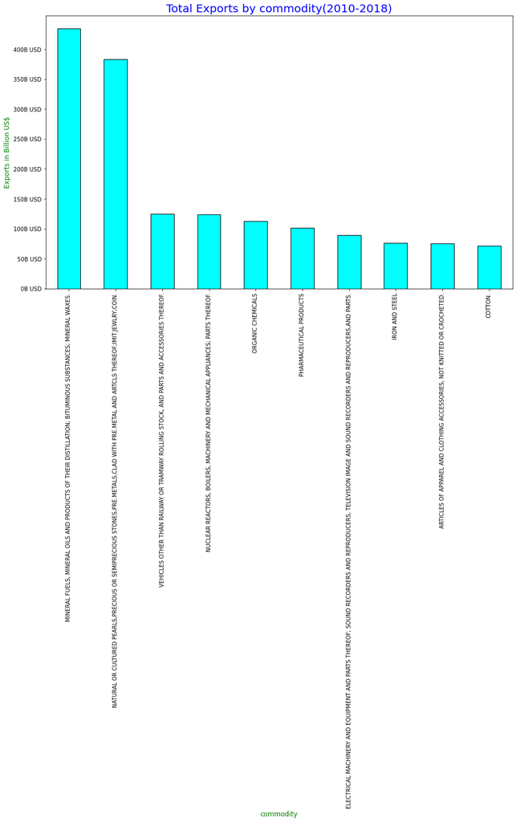

```python
### which Indian commodity was exported(highest in value)
plt.figure(figsize=[15,9])
a=exp.groupby(by=['Commodity'])['value'].sum().sort_values(ascending=False).head(10)
a.plot(kind='bar',color='cyan',edgecolor='black')
plt.xlabel('commodity',fontdict={'fontsize': 12,'color':'green'})
plt.ylabel('Exports in Billion US$',fontdict={'fontsize': 12,'color':'green'})
plt.title('Total Exports by commodity(2010-2018)',fontdict={'fontsize': 20,'color':'Blue'})
ticks = np.arange(0, 450000, 50000)
labels = ["{}B USD".format(i//1000) for i in ticks]
plt.yticks(ticks, labels)
plt.show()
```

*Mineral wax,mineral fuel and other mineral product commodity was exported highest during 2010-2018*

```python
exp.info()
```

```
<class 'pandas.core.frame.DataFrame'>
RangeIndex: 137023 entries, 0 to 137022
Data columns (total 5 columns):
 #   Column     Non-Null Count   Dtype
---  ------     --------------   -----
 0   HSCode     137023 non-null  int64
 1   Commodity  137023 non-null  object
 2   value      122985 non-null  float64
 3   country    137023 non-null  object
 4   year       137023 non-null  int64
dtypes: float64(1), int64(2), object(2)
memory usage: 5.2+ MB
```

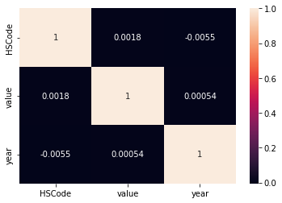

```python
expcorr=exp.corr()
sns.heatmap(expcorr,annot=True)
plt.show()
```

*No relationship found*

# Import Data

```python
imp=pd.read_csv('/kaggle/input/india-trade-data/2018-2010_import.csv')
imp.head()
```

|  | HSCode | Commodity | value | country | year |
| --- | --- | --- | --- | --- | --- |
| 0 | 5 | PRODUCTS OF ANIMAL ORIGIN, NOT ELSEWHERE SPECI... | 0.00 | AFGHANISTAN TIS | 2018 |
| 1 | 7 | EDIBLE VEGETABLES AND CERTAIN ROOTS AND TUBERS. | 12.38 | AFGHANISTAN TIS | 2018 |
| 2 | 8 | EDIBLE FRUIT AND NUTS; PEEL OR CITRUS FRUIT OR... | 268.60 | AFGHANISTAN TIS | 2018 |
| 3 | 9 | COFFEE, TEA, MATE AND SPICES. | 35.48 | AFGHANISTAN TIS | 2018 |
| 4 | 11 | PRODUCTS OF THE MILLING INDUSTRY; MALT; STARCH... | NaN | AFGHANISTAN TIS | 2018 |

```python
### checking Data types

imp.dtypes
```

```
HSCode         int64
Commodity     object
value        float64
country       object
year           int64
dtype: object
```

-------------------------------------------------------> Datatypes are good

```python
### Checking for null values

imp.isnull().sum()
```

```
HSCode           0
Commodity        0
value        11588
country          0
year             0
dtype: int64
```

# Sanity Check for Import data

```python
### Value must be >=0

imp[imp['value']<0.0].shape[0]
```

```
0
```

# Visualization for Import data

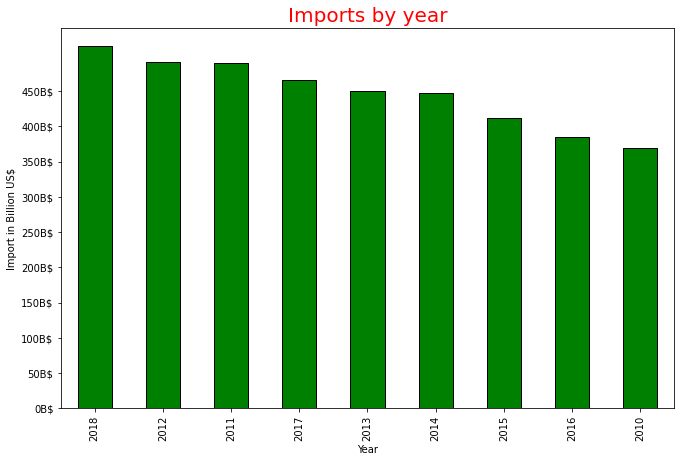

```python
### In Which year India imported highest in value
plt.figure(figsize=[11,7])
imp.groupby(by='year')['value'].sum().sort_values(ascending=False).plot.bar(color='green',edgecolor='Black')
plt.xlabel('Year')
plt.ylabel('Import in Billion US$')
ticks = np.arange(0, 500000, 50000)
labels = ["{}B$".format(i//1000) for i in ticks]
plt.yticks(ticks, labels)
plt.title('Imports by year',fontdict={'fontsize': 20,'color':'Red'})
plt.show()
```

*In 2018 India imported highest*

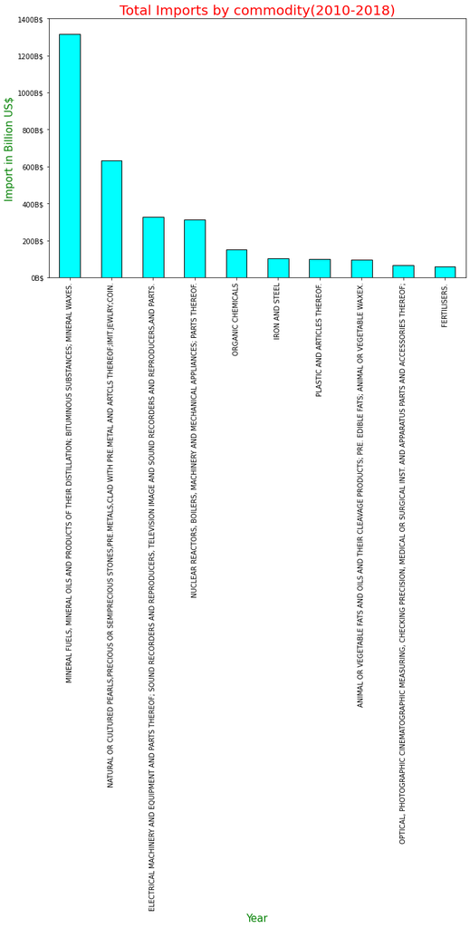

```python
### Which commmodity has been imported highest by value?
plt.figure(figsize=[11,7])
imp_by_com=imp.groupby(by=['Commodity'])['value'].sum().sort_values(ascending=False).head(10)
imp_by_com.plot(kind='bar',color='cyan',edgecolor='black')
plt.xlabel('Year',fontdict={'fontsize': 15,'color':'green'})
plt.ylabel('Import in Billion US$',fontdict={'fontsize': 15,'color':'green'})
ticks = np.arange(0, 1600000, 200000)
labels = ["{}B$".format(i//1000) for i in ticks]
plt.yticks(ticks, labels)
plt.title('Total Imports by commodity(2010-2018)',fontdict={'fontsize': 20,'color':'Red'})
plt.show()
```

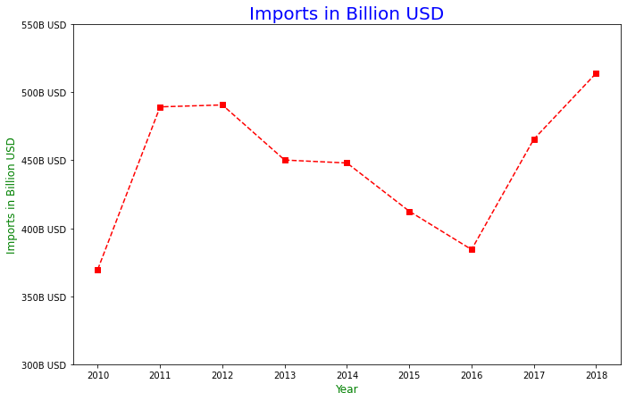

```python
### Imports trend during 2010-2018 using line plot
plt.figure(figsize=[11,7])
imp.groupby(by='year')['value'].sum().plot.line(color='red',marker='s',linestyle='--')
ticks = np.arange(300000, 600000, 50000)
labels = ["{}B USD".format(i//1000) for i in ticks]
plt.yticks(ticks, labels)
plt.xlabel('Year',fontdict={'fontsize': 12,'color':'green'})
plt.ylabel('Imports in Billion USD',fontdict={'fontsize': 12,'color':'green'})
plt.title('Imports in Billion USD',fontdict={'fontsize': 20,'color':'Blue'})
plt.show()
```

# Merged Import-Export data

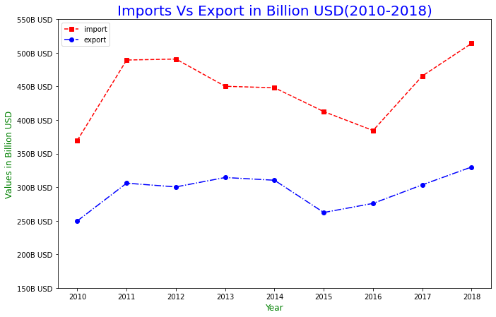

```python
### We can compare Import Vs. Export during 2010-2018

plt.figure(figsize=[11,7])
imp.groupby(by='year')['value'].sum().plot.line(color='red',marker='s',linestyle='--',label='import')
exp.groupby(by='year')['value'].sum().plot.line(color='blue',marker='o',linestyle='-.',label='export')
ticks = np.arange(150000, 600000, 50000)
labels = ["{}B USD".format(i//1000) for i in ticks]
plt.yticks(ticks, labels)
plt.xlabel('Year',fontdict={'fontsize': 12,'color':'green'})
plt.ylabel('Values in Billion USD',fontdict={'fontsize': 12,'color':'green'})
plt.title('Imports Vs Export in Billion USD(2010-2018)',fontdict={'fontsize': 20,'color':'Blue'})
plt.legend()
plt.show()
```

*India has been net importer in any year.*

```python
x=imp.groupby(by='year')['value'].sum()
y=exp.groupby(by='year')['value'].sum()
print(min(x-y))
print(max(x-y))
print(x-y)
```

```
108515.02000000002
190345.75
year
2010    119961.07
2011    183363.53
2012    190345.75
2013    135804.38
2014    137705.61
2015    150263.23
2016    108515.02
2017    162066.17
2018    184012.69
Name: value, dtype: float64
```

*In 2016 trade gap was narrowest*

*In 2012 trade gap was widest*

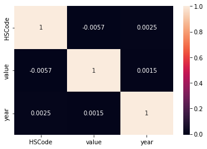

```python
### Finding corelation for import data

impcorr=imp.corr()
sns.heatmap(impcorr,annot=True)
plt.show()
```

###### No relationship found

```python
### Grouping countries for export data
df1=exp.groupby(by='country')['value'].sum()
df1.head()
```

```
country
AFGHANISTAN TIS    4760.19
ALBANIA             196.51
ALGERIA            8232.24
AMERI SAMOA           3.40
ANDORRA               6.28
Name: value, dtype: float64
```

```python
### Grouping countries for import data
df2=imp.groupby(by='country')['value'].sum()
df2.head()
```

```
country
AFGHANISTAN TIS     2686.62
ALBANIA              524.18
ALGERIA            10185.73
AMERI SAMOA            5.82
ANDORRA                5.45
Name: value, dtype: float64
```

```python
### Merging data frame on country

df3=pd.merge(df1,df2,on='country')
df3.head()
```

| country | value_x | value_y |
| --- | --- | --- |
| AFGHANISTAN TIS | 4760.19 | 2686.62 |
| ALBANIA | 196.51 | 524.18 |
| ALGERIA | 8232.24 | 10185.73 |
| AMERI SAMOA | 3.40 | 5.82 |
| ANDORRA | 6.28 | 5.45 |

```python
df3.rename(columns={'value_x':'export_val','value_y':'import_val'},inplace=True)
```

```python
df3.head()
```

| country | export_val | import_val |
| --- | --- | --- |
| AFGHANISTAN TIS | 4760.19 | 2686.62 |
| ALBANIA | 196.51 | 524.18 |
| ALGERIA | 8232.24 | 10185.73 |
| AMERI SAMOA | 3.40 | 5.82 |
| ANDORRA | 6.28 | 5.45 |

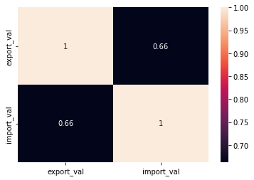

```python
### Finding correlation b/w exoprt and import value
value_corr=df3.corr()
sns.heatmap(value_corr,annot=True)
plt.show()
```

*We can say that export_val and import_val are moderately positive correlated*

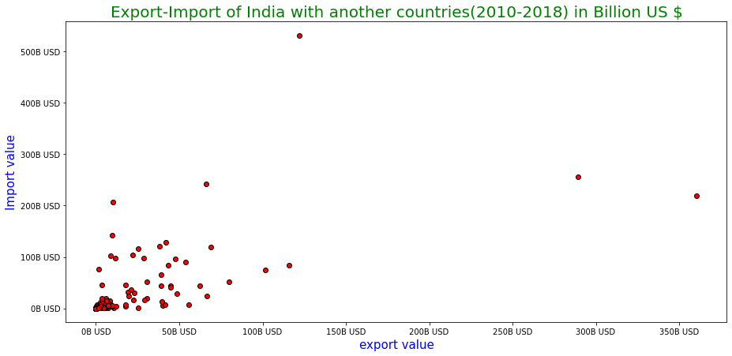

```python
plt.figure(figsize=[15,7])
plt.scatter(df3.export_val,df3.import_val,marker='o',edgecolor='black',color='red')
plt.ylabel('Import value',fontdict={'fontsize':15,'color':'blue'})
plt.xlabel('export value',fontdict={'fontsize':15,'color':'blue'})
ticks_y = np.arange(0, 600000, 100000)
ticks_x = np.arange(0, 400000, 50000)
labels_y = ["{}B USD".format(i//1000) for i in ticks_y]
labels_x = ["{}B USD".format(i//1000) for i in ticks_x]
plt.yticks(ticks_y, labels_y)
plt.xticks(ticks_x, labels_x)
plt.title('Export-Import of India with another countries(2010-2018) in Billion US $',fontdict={'fontsize':20,'color':'green'})
plt.show()
```

```python
### Making a column for trade difference to find out with which country India a been net exoprter and with a net importer?

df3['trade_diff']=df3['export_val']-df3['import_val']
df3.head()
```

| country | export_val | import_val | trade_diff |
| --- | --- | --- | --- |
| AFGHANISTAN TIS | 4760.19 | 2686.62 | 2073.57 |
| ALBANIA | 196.51 | 524.18 | -327.67 |
| ALGERIA | 8232.24 | 10185.73 | -1953.49 |
| AMERI SAMOA | 3.40 | 5.82 | -2.42 |
| ANDORRA | 6.28 | 5.45 | 0.83 |

```python
df3['NE/NI']=df3['trade_diff'].apply(lambda x: 'NE' if x>0 else 'NI')

### NE means Net Exporter
### NI means Net Importer
df3.head()
```

| country | export_val | import_val | trade_diff | NE/NI |
| --- | --- | --- | --- | --- |
| AFGHANISTAN TIS | 4760.19 | 2686.62 | 2073.57 | NE |
| ALBANIA | 196.51 | 524.18 | -327.67 | NI |
| ALGERIA | 8232.24 | 10185.73 | -1953.49 | NI |
| AMERI SAMOA | 3.40 | 5.82 | -2.42 | NI |
| ANDORRA | 6.28 | 5.45 | 0.83 | NE |

```python
### With How many country India have been Net Exporter and Net Importer.


#plt.figure(figsize=[10,5])
df3['NE/NI'].value_counts(normalize=True)
```

```
NE    0.595041
NI    0.404959
Name: NE/NI, dtype: float64
```

*With 59.5% countries India's trade have been surplus and with 40.5% countries India's trade have been deficit*

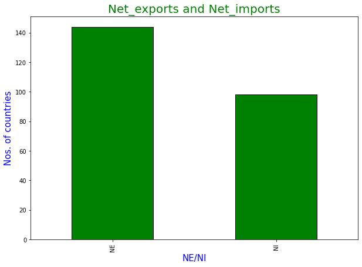

```python
### lets understand With bar graph
plt.figure(figsize=[10,7])
df3['NE/NI'].value_counts().plot.bar(color='green',edgecolor='black')
plt.title('Net_exports and Net_imports',fontdict={'fontsize':20,'color':'green'})
plt.ylabel('Nos. of countries',fontdict={'fontsize':15,'color':'blue'})
plt.xlabel('NE/NI',fontdict={'fontsize':15,'color':'blue'})
plt.show()
```

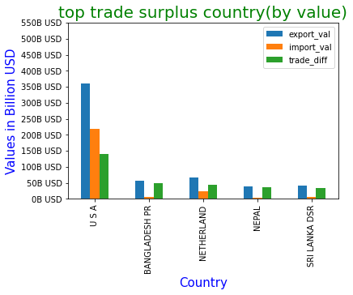

```python
### Which are top 5 countries to which India exports more and imoprt less?

plt.figure(figsize=[11,7])
top5=df3.sort_values(by='trade_diff',ascending=False).head(5)
top5.plot(kind='bar')
ticks = np.arange(0, 600000, 50000)
labels = ["{}B USD".format(i//1000) for i in ticks]
plt.yticks(ticks, labels)
plt.title('top trade surplus country(by value)',fontdict={'fontsize':20,'color':'green'})
plt.ylabel('Values in Billion USD',fontdict={'fontsize':15,'color':'blue'})
plt.xlabel('Country',fontdict={'fontsize':15,'color':'blue'})
plt.show()
```

*With USA India's surplus trade has been highest*

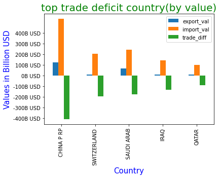

```python
### Which are top 5 countries to which India imports more and export less?

plt.figure(figsize=[11,7])
top5=df3.sort_values(by='trade_diff',ascending=True).head(5)
top5.plot(kind='bar')
ticks = np.arange(-400000, 500000, 100000)
labels = ["{}B USD".format(i//1000) for i in ticks]
plt.yticks(ticks, labels)
plt.title('top trade deficit country(by value)',fontdict={'fontsize':20,'color':'green'})
plt.ylabel('Values in Billion USD',fontdict={'fontsize':15,'color':'blue'})
plt.xlabel('Country',fontdict={'fontsize':15,'color':'blue'})
plt.show()
```

*With China India's deficit trade has been highest*

```python
### Which countries are  India's top 5 trade partner?

df3['total trade']=df3['export_val']+df3['import_val']
df3.head()
```

| country | export_val | import_val | trade_diff | NE/NI | total trade |
| --- | --- | --- | --- | --- | --- |
| AFGHANISTAN TIS | 4760.19 | 2686.62 | 2073.57 | NE | 7446.81 |
| ALBANIA | 196.51 | 524.18 | -327.67 | NI | 720.69 |
| ALGERIA | 8232.24 | 10185.73 | -1953.49 | NI | 18417.97 |
| AMERI SAMOA | 3.40 | 5.82 | -2.42 | NI | 9.22 |
| ANDORRA | 6.28 | 5.45 | 0.83 | NE | 11.73 |

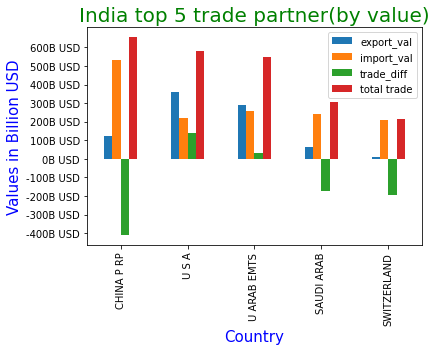

```python
plt.figure(figsize=[11,7])
df3.sort_values(by='total trade',ascending=False).head(5).plot.bar()
ticks = np.arange(-400000, 700000, 100000)
labels = ["{}B USD".format(i//1000) for i in ticks]
plt.yticks(ticks, labels)
plt.title('India top 5 trade partner(by value)',fontdict={'fontsize':20,'color':'green'})
plt.ylabel('Values in Billion USD',fontdict={'fontsize':15,'color':'blue'})
plt.xlabel('Country',fontdict={'fontsize':15,'color':'blue'})
plt.show()
```

*China is India's top trading partner followed by USA*

```python
c=df3.corr()
c
```

|  | export_val | import_val | trade_diff | total trade |
| --- | --- | --- | --- | --- |
| export_val | 1.000000 | 0.662867 | 0.018169 | 0.872865 |
| import_val | 0.662867 | 1.000000 | -0.736570 | 0.943948 |
| trade_diff | 0.018169 | -0.736570 | 1.000000 | -0.472022 |
| total trade | 0.872865 | 0.943948 | -0.472022 | 1.000000 |

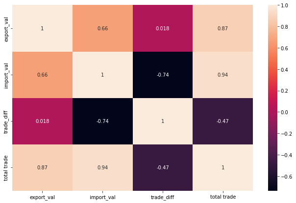

```python
plt.figure(figsize=[11,7])
c=df3.corr()
sns.heatmap(c,annot=True)
plt.show()
```

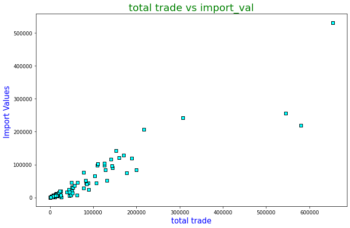

```python
plt.figure(figsize=[11,7])
plt.scatter(data=df3,x='total trade',y='import_val',marker='s',color='cyan',edgecolor='black')
plt.title('total trade vs import_val',fontdict={'fontsize':20,'color':'green'})
plt.ylabel('Import Values ',fontdict={'fontsize':15,'color':'blue'})
plt.xlabel('total trade',fontdict={'fontsize':15,'color':'blue'})
plt.show()
```

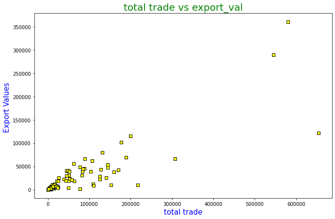

```python
plt.figure(figsize=[11,7])
plt.scatter(data=df3,x='total trade',y='export_val',marker='s',color='yellow',edgecolor='black')
plt.title('total trade vs export_val',fontdict={'fontsize':20,'color':'green'})
plt.ylabel('Export Values ',fontdict={'fontsize':15,'color':'blue'})
plt.xlabel('total trade',fontdict={'fontsize':15,'color':'blue'})
plt.show()
```

```python
### Export dataset grouped by country and year

exp_grpby_yr=exp.groupby(by=['country','year'])['value'].sum()
exp_grpby_yr.head()
```

```
country          year
AFGHANISTAN TIS  2010    422.31
                 2011    510.81
                 2012    472.55
                 2013    474.26
                 2014    422.48
Name: value, dtype: float64
```

```python
### Import dataset grouped by country and year

imp_grpby_yr=imp.groupby(by=['country','year'])['value'].sum()
imp_grpby_yr.head()
```

```
country          year
AFGHANISTAN TIS  2010    146.01
                 2011    132.49
                 2012    159.53
                 2013    208.76
                 2014    261.92
Name: value, dtype: float64
```

```python
### Merge both dataset which grouped by country and year both

merged_grp=pd.merge(exp_grpby_yr,imp_grpby_yr,on=['country','year'])
merged_grp.head()
```

| country | year | value_x | value_y |
| --- | --- | --- | --- |
| AFGHANISTAN TIS | 2010 | 422.31 | 146.01 |
|  | 2011 | 510.81 | 132.49 |
|  | 2012 | 472.55 | 159.53 |
|  | 2013 | 474.26 | 208.76 |
|  | 2014 | 422.48 | 261.92 |

```python
###Reseting index
merged_grp.reset_index(inplace=True)
```

```python
### raname column names

merged_grp.rename(columns={'value_x':'val_exp','value_y':'val_imp'},inplace=True)
merged_grp.head()
```

|  | country | year | val_exp | val_imp |
| --- | --- | --- | --- | --- |
| 0 | AFGHANISTAN TIS | 2010 | 422.31 | 146.01 |
| 1 | AFGHANISTAN TIS | 2011 | 510.81 | 132.49 |
| 2 | AFGHANISTAN TIS | 2012 | 472.55 | 159.53 |
| 3 | AFGHANISTAN TIS | 2013 | 474.26 | 208.76 |
| 4 | AFGHANISTAN TIS | 2014 | 422.48 | 261.92 |

```python
### Adding columnn net_val
merged_grp['net_trade']=merged_grp['val_exp']-merged_grp['val_imp']
merged_grp.head()
```

|  | country | year | val_exp | val_imp | net_trade |
| --- | --- | --- | --- | --- | --- |
| 0 | AFGHANISTAN TIS | 2010 | 422.31 | 146.01 | 276.30 |
| 1 | AFGHANISTAN TIS | 2011 | 510.81 | 132.49 | 378.32 |
| 2 | AFGHANISTAN TIS | 2012 | 472.55 | 159.53 | 313.02 |
| 3 | AFGHANISTAN TIS | 2013 | 474.26 | 208.76 | 265.50 |
| 4 | AFGHANISTAN TIS | 2014 | 422.48 | 261.92 | 160.56 |

#### Next,we will find export and import trend for india top 3 trade partner

```python
###For CHINA

CHINA=merged_grp[merged_grp['country']=='CHINA P RP']
CHINA
```

|  | country | year | val_exp | val_imp | net_trade |
| --- | --- | --- | --- | --- | --- |
| 378 | CHINA P RP | 2010 | 14168.65 | 43479.39 | -29310.74 |
| 379 | CHINA P RP | 2011 | 18076.34 | 55313.17 | -37236.83 |
| 380 | CHINA P RP | 2012 | 13534.66 | 52247.97 | -38713.31 |
| 381 | CHINA P RP | 2013 | 14824.16 | 51034.30 | -36210.14 |
| 382 | CHINA P RP | 2014 | 11934.07 | 60412.84 | -48478.77 |
| 383 | CHINA P RP | 2015 | 9011.19 | 61707.54 | -52696.35 |
| 384 | CHINA P RP | 2016 | 10171.66 | 61282.66 | -51111.00 |
| 385 | CHINA P RP | 2017 | 13333.33 | 76380.35 | -63047.02 |
| 386 | CHINA P RP | 2018 | 16751.94 | 70319.29 | -53567.35 |

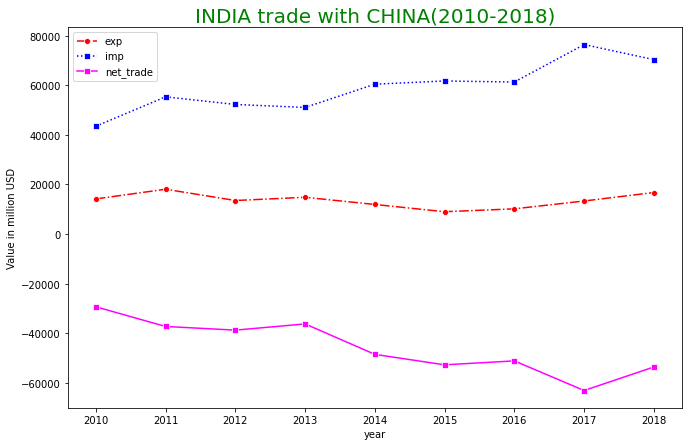

```python
### lINEPLOT FOR INDIA'S TRADE WITH CHINA BETWEEN 2010-2018


plt.figure(figsize=[11,7])
# CHINA = merged_grp.query("COUNTRY == 'CHINA P RP'")
sns.lineplot(data=CHINA, x="year", y="val_exp",label='exp',marker='o',color='red',linestyle='-.')
sns.lineplot(data=CHINA, x="year", y="val_imp",label='imp',marker='s',color='blue',linestyle=':')
sns.lineplot(data=CHINA, x="year", y="net_trade",label='net_trade',marker='s',color='magenta',linestyle='-')
plt.title('INDIA trade with CHINA(2010-2018)',fontdict={'fontsize':20,'color':'green'})
plt.ylabel('Value in million USD')
plt.legend()
plt.show()
```

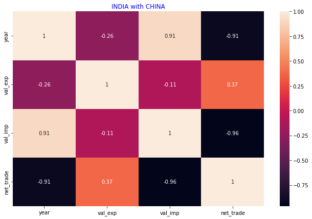

```python
### Heatmap for India trade with CHINA
plt.figure(figsize=[11,7])
CHINA_corr=CHINA.corr()
sns.heatmap(CHINA_corr,annot=True)
plt.title('INDIA with CHINA',color='Blue')
plt.show()
```

```python
### For USA
USA=merged_grp[merged_grp['country']=='U S A']
USA
```

|  | country | year | val_exp | val_imp | net_trade |
| --- | --- | --- | --- | --- | --- |
| 1913 | U S A | 2010 | 25291.56 | 20050.41 | 5241.15 |
| 1914 | U S A | 2011 | 34741.33 | 23454.64 | 11286.69 |
| 1915 | U S A | 2012 | 36154.88 | 25204.39 | 10950.49 |
| 1916 | U S A | 2013 | 39141.81 | 22504.79 | 16637.02 |
| 1917 | U S A | 2014 | 42448.30 | 21814.27 | 20634.03 |
| 1918 | U S A | 2015 | 40335.68 | 21781.06 | 18554.62 |
| 1919 | U S A | 2016 | 42211.96 | 22307.18 | 19904.78 |
| 1920 | U S A | 2017 | 47878.17 | 26610.72 | 21267.45 |
| 1921 | U S A | 2018 | 52405.88 | 35549.20 | 16856.68 |

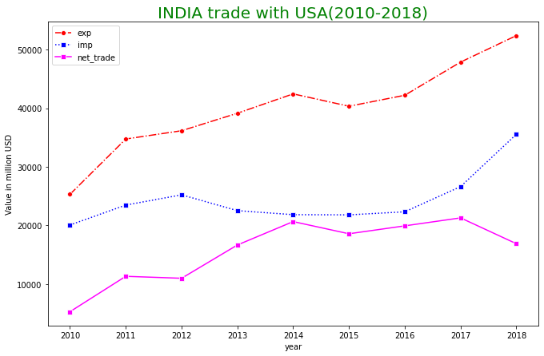

```python
### lINEPLOT FOR INDIA'S TRADE WITH USA BETWEEN 2010-2018



plt.figure(figsize=[11,7])
sns.lineplot(data=USA, x="year", y="val_exp",label='exp',marker='o',color='red',linestyle='-.')
sns.lineplot(data=USA, x="year", y="val_imp",label='imp',marker='s',color='blue',linestyle=':')
sns.lineplot(data=USA, x="year", y="net_trade",label='net_trade',marker='s',color='magenta',linestyle='-')
plt.title('INDIA trade with USA(2010-2018)',fontdict={'fontsize':20,'color':'green'})
plt.ylabel('Value in million USD')
plt.legend()
plt.show()
```

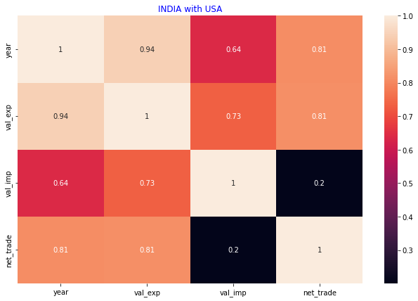

```python
### Heatmap for India trade with USA


plt.figure(figsize=[11,7])
USA_corr=USA.corr()
sns.heatmap(USA_corr,annot=True)
plt.title('INDIA with USA',color='Blue')
plt.show()
```

```python
###For UAE

UAE=merged_grp[merged_grp['country']=='U ARAB EMTS']
UAE
```

|  | country | year | val_exp | val_imp | net_trade |
| --- | --- | --- | --- | --- | --- |
| 1895 | U ARAB EMTS | 2010 | 33822.08 | 32753.02 | 1069.06 |
| 1896 | U ARAB EMTS | 2011 | 35925.23 | 36756.16 | -830.93 |
| 1897 | U ARAB EMTS | 2012 | 36316.29 | 39138.21 | -2821.92 |
| 1898 | U ARAB EMTS | 2013 | 30520.08 | 29019.66 | 1500.42 |
| 1899 | U ARAB EMTS | 2014 | 33027.73 | 26139.73 | 6888.00 |
| 1900 | U ARAB EMTS | 2015 | 30316.16 | 19445.54 | 10870.62 |
| 1901 | U ARAB EMTS | 2016 | 31175.16 | 21509.69 | 9665.47 |
| 1902 | U ARAB EMTS | 2017 | 28145.77 | 21738.98 | 6406.79 |
| 1903 | U ARAB EMTS | 2018 | 30126.38 | 29785.09 | 341.29 |

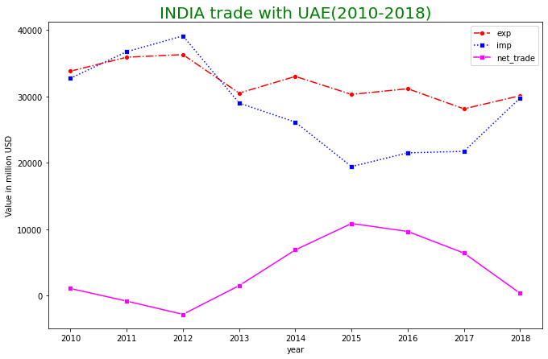

```python
### LINEPLOT FOR INDIA'S TRADE WITH UAE BETWEEN 2010-2018


plt.figure(figsize=[11,7])
sns.lineplot(data=UAE, x="year", y="val_exp",label='exp',marker='o',color='red',linestyle='-.')
sns.lineplot(data=UAE, x="year", y="val_imp",label='imp',marker='s',color='blue',linestyle=':')
sns.lineplot(data=UAE, x="year", y="net_trade",label='net_trade',marker='s',color='magenta',linestyle='-')
plt.title('INDIA trade with UAE(2010-2018)',fontdict={'fontsize':20,'color':'green'})
plt.ylabel('Value in million USD')
plt.legend()
plt.show()
```

[figure not shown]

```python
### Heatmap for India trade with Uae


plt.figure(figsize=[11,7])
UAE_corr=USA.corr()
sns.heatmap(USA_corr,annot=True)
plt.title('INDIA with UAE',color='Blue')
plt.show()
```

*These are the trade analysis of india top 3 trade partner(by value),we can do for all countries*

```python
d=merged_grp.groupby(by=['year','country'])['net_trade'].sum().sort_values(ascending=False)
d.reset_index()
d
```

```
year  country
2017  U S A         21267.45
2014  U S A         20634.03
2016  U S A         19904.78
2015  U S A         18554.62
2018  U S A         16856.68
                      ...
2014  CHINA P RP   -48478.77
2016  CHINA P RP   -51111.00
2015  CHINA P RP   -52696.35
2018  CHINA P RP   -53567.35
2017  CHINA P RP   -63047.02
Name: net_trade, Length: 2055, dtype: float64
```

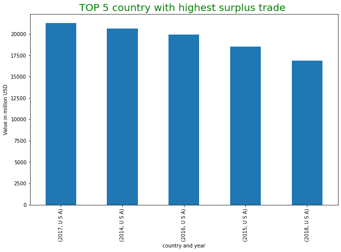

```python
plt.figure(figsize=[11,7])
d=merged_grp.groupby(by=['year','country'])['net_trade'].sum().sort_values(ascending=False).head(5)
d.plot(kind='bar')
plt.title('TOP 5 country with highest surplus trade ',fontdict={'fontsize':20,'color':'green'})
plt.ylabel('Value in million USD')
plt.xlabel('country and year')
plt.show()
```

*India's highest surplus trade in 2017 with USA*

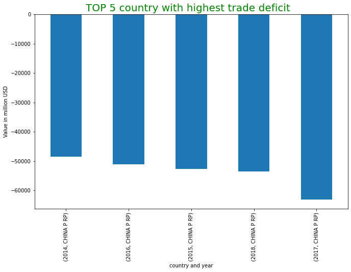

```python
plt.figure(figsize=[11,7])
d=merged_grp.groupby(by=['year','country'])['net_trade'].sum().sort_values(ascending=False).tail(5)
d.plot(kind='bar')
plt.title('TOP 5 country with highest trade deficit  ',fontdict={'fontsize':20,'color':'green'})
plt.ylabel('Value in million USD')
plt.xlabel('country and year')
plt.show()
```

*India's highest deficit trade was in 2017 and with CHINA*

*IN 2017,FOR INDIA TRADE DEFICIT WAS HIGHEST(WITH CHINA) AND TRADE SURPLUS(WITH USA) AS WELL*

```python
merged_grp['total trade']=merged_grp['val_imp']+merged_grp['val_exp']
merged_grp
```

|  | country | year | val_exp | val_imp | net_trade | total trade |
| --- | --- | --- | --- | --- | --- | --- |
| 0 | AFGHANISTAN TIS | 2010 | 422.31 | 146.01 | 276.30 | 568.32 |
| 1 | AFGHANISTAN TIS | 2011 | 510.81 | 132.49 | 378.32 | 643.30 |
| 2 | AFGHANISTAN TIS | 2012 | 472.55 | 159.53 | 313.02 | 632.08 |
| 3 | AFGHANISTAN TIS | 2013 | 474.26 | 208.76 | 265.50 | 683.02 |
| 4 | AFGHANISTAN TIS | 2014 | 422.48 | 261.92 | 160.56 | 684.40 |
| ... | ... | ... | ... | ... | ... | ... |
| 2050 | ZIMBABWE | 2014 | 223.84 | 32.69 | 191.15 | 256.53 |
| 2051 | ZIMBABWE | 2015 | 205.01 | 24.44 | 180.57 | 229.45 |
| 2052 | ZIMBABWE | 2016 | 109.02 | 60.45 | 48.57 | 169.47 |
| 2053 | ZIMBABWE | 2017 | 163.46 | 62.20 | 101.26 | 225.66 |
| 2054 | ZIMBABWE | 2018 | 181.62 | 7.81 | 173.81 | 189.43 |

2055 rows × 6 columns

```python
d=merged_grp.groupby(by=['year','country'])['total trade'].sum()
d
```

```
year  country
2010  AFGHANISTAN TIS     568.32
      ALBANIA              11.60
      ALGERIA            2598.11
      AMERI SAMOA           0.35
      ANDORRA               0.28
                          ...
2018  VIRGIN IS US         43.29
      WALLIS F IS           0.00
      YEMEN REPUBLC       753.00
      ZAMBIA              829.40
      ZIMBABWE            189.43
Name: total trade, Length: 2055, dtype: float64
```

*Inferences 1: In 2018,India exported highest(in value) while in 2010 it was lowest*

*Inference 2:India's export is continously increasing after 2015*

*Inference 3: India exported highest(in value) to USA(2010-2018)*

*Inference 4:Mineral wax,mineral fuel and other mineral product commodity was exported highes during 2010-2018*

*Inference 5: In 2018 India imported highest while in 2010 it was lowest*

*Inference 6: In 2018,India exports and imports are highest*

*Inference 7: In 2010,India exports and imports are lowest*

*Inference 8 :In commodity,Mineral wax,mineral fuel and other mineral product was imported highest during 2010-2018*

*Inference 9: India has been net importer in any year*

*Inference 10: In 2016 trade gap was narrowest*

*Inference 11: In 2012 trade gap was widest*

*Inference 12: We can say that export_val and import_val are moderately positive correlated.Correlation coefficient=0.66*

*Inference 13: With 59.5% countries India's trade have been surplus and with 40.5% countries India,s have been deficit*

*Inference 14: USA has been topmost surplus trade partner during()2010-2018*

*Inference 15: China has been topmost deficit trade partner for India during()2010-2018*

*Inference 17:India's highest surplus trade was in 2017 with USA*

*Inference 18:India's highest deficit trade was in 2017 with China*